# Seurat_processing

Viswanadham Sridhara

2025-02-24

## R Markdown

Most of the RNA-seq experiments focus on bulk RNA-seq methods. However, after closely looking at single cell datasets, the information obtained from single-cell experiments can throw light on variety of underlying biological processes. Here, I downloaded publicly available PMBC dataset to show how this package can be used to run Seurat analyses with minimum parameters list. The reason to create this package is to arrange the Seurat functionality into modules for easy preprocessing, and cell clustering.

In addition, the module can also be used for batch correction, cell-type annotation, and to transfer annotations from reference dataset to the current dataset (using SingleR and celldex annotations).

10X PBMC data can be found here: https://cf.10xgenomics.com/samples/cell/pbmc3k/pbmc3k_filtered_gene_bc_matrices.tar.gz

```r
counts_data <- Read10X(data.dir = "../../scPipelineMISCdata/data/pbmc3k/filtered_gene_bc_matrices/hg19")
```

## Entire Seurat analysis from counts data to cell clustering using 2 functions

Using SeuratPreprocess and SeuratLowDim, the user can go directly from counts data, to clusters identified (t-SNE, UMAP).

```
## Normalizing layer: counts
```

```
## Finding variable features for layer counts
```

```
## PC_ 1
## Positive:  MALAT1, LTB, IL32, CD2, ACAP1
## Negative:  CST3, TYROBP, FTL, LYZ, AIF1
## PC_ 2
## Positive:  CD79A, MS4A1, HLA-DQA1, HLA-DQB1, HLA-DRA
## Negative:  NKG7, PRF1, GZMA, CST7, GZMB
## PC_ 3
## Positive:  PPBP, PF4, SDPR, NRGN, GNG11
## Negative:  HLA-DPA1, HLA-DPB1, CD74, HLA-DQA1, HLA-DRB1
## PC_ 4
## Positive:  VIM, IL32, S100A8, MAL, GIMAP7
## Negative:  HLA-DQA1, CD74, CD79B, CD79A, HLA-DPB1
## PC_ 5
## Positive:  S100A8, S100A9, GZMB, FGFBP2, GNLY
## Negative:  TUBA1B, CKB, LTB, MS4A7, HN1
```

```
## Modularity Optimizer version 1.3.0 by Ludo Waltman and Nees Jan van Eck
##
## Number of nodes: 2700
## Number of edges: 131872
##
## Running Louvain algorithm...
## Maximum modularity in 10 random starts: 0.5481
## Number of communities: 18
## Elapsed time: 0 seconds
```

## Plots

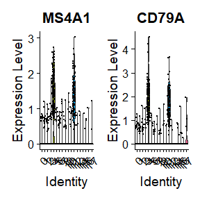

[figure not shown]

## Identify differentially expressed genes (markers list using Seurat)

The output seurat_markers has both the markers list, as well as a subset of the markers list, that are highly confident, both of which are stored in list.

[output not shown]

Plotting markers by clusters with a threshold of log2FC greater than 1, and using the top 10 genes for each cluster.

[figure not shown]

## Next, Identify Reactome Pathways using DE gene list (using ReactomeGSA package)

```
## Converting expression data to string... (This may take a moment)
```

```
## Conversion complete
```

```
## Compressing request data...
```

```
## Reactome Analysis submitted succesfully
```

# Return the results

seurat_reactome has 3 items in the list(gsva_result = gsva_result, pathway_expression = pathway_expression, max_difference = max_difference)

Expression of different pathways e.g.,

```r
  head(seurat_reactome[[2]], n = 3)
```

```
##                                          Name          X0          X1
## R-HSA-1059683         Interleukin-6 signaling -0.17142781 -0.15764328
## R-HSA-109606  Intrinsic Pathway for Apoptosis -0.06789919 -0.05423535
## R-HSA-109703              PKB-mediated events -0.17463572 -0.07081801
##                       X10         X11         X12         X13         X14
## R-HSA-1059683 -0.19858575 -0.12649482 -0.13298873 -0.15162568 -0.17703086
## R-HSA-109606  -0.06630106 -0.07582569 -0.06535638 -0.06887011 -0.06556512
## R-HSA-109703  -0.04142919  0.08474367 -0.19781114 -0.17693089 -0.17576696
##                       X15         X16         X17          X2          X3
## R-HSA-1059683 -0.13092133 -0.17719506 -0.01370706 -0.13670632 -0.18095835
## R-HSA-109606  -0.01665722 -0.08295779  0.04412151 -0.04896014 -0.08348308
## R-HSA-109703   0.16180087 -0.17995634 -0.07282577 -0.08341424 -0.14237353
##                        X4          X5          X6          X7           X8
## R-HSA-1059683 -0.15426816 -0.16405041 -0.14025893 -0.17710836 -0.119597499
## R-HSA-109606  -0.08189573 -0.05950747 -0.05366512 -0.06922637 -0.032297973
## R-HSA-109703  -0.13737609 -0.15082192 -0.12792425 -0.13959058 -0.009805199
##                        X9
## R-HSA-1059683 -0.17664452
## R-HSA-109606  -0.07570051
## R-HSA-109703  -0.13764875
```

Min, max and differential Expression of different pathways e.g.,

```r
  head(seurat_reactome[[3]], n = 3)
```

```
##                                                         name        min
## R-HSA-9636003              NEIL3-mediated resolution of ICLs -0.9946563
## R-HSA-1299316 TWIK-releated acid-sensitive K+ channel (TASK) -0.9910129
## R-HSA-211994           Sterols are 12-hydroxylated by CYP8B1 -0.8350945
##                     max     diff
## R-HSA-9636003 0.9497207 1.944377
## R-HSA-1299316 0.9400049 1.931018
## R-HSA-211994  0.9451417 1.780236
```